# DS105-05-02 - ANOVAs - Repeated Measures - in R

## Load Libraries

```r
install.packages("fastR2")
install.packages("car")
library("rcompanion")
library("fastR2")
library("car")
```

## Load in Data

```r
breakfast <- read.csv("./assets/breakfast.csv")

  # View data
    head(breakfast)
```

|  | Participant.Code | Treatment.Group | Age..y. | Sex | Height..m. | Baseline.Body.Mass..kg. | Follow.Up.Body.Mass..kg. | Baseline.Lean.Tissue.Mass..kg. | Follow.Up.Lean.Tissue.Mass..kg. | Baseline.Adipose.Tissue.Mass..kg. | Follow.Up.Adipose.Tissue.Mass..kg. | Baseline.BMI..kg.m.2. | Follow.Up.BMI..kg.m.2. | Baseline.FMI..kg.m.2. | Folow.Up.FMI..kg.m.2. | Baseline.Body.Fat.... | Follow.Up.Body.Fat.... | Baseline.Waist.Circumference..cm. | Follow.Up.Waist.Circumference..cm. | Baseline.Waist.Hip.Ratio | Follow.Up.Waist.Hip.Ratio | Baseline.Sagittal.Abdominal.Diameter..cm. | Follow.Up.Sagittal.Abdominal.Diameter..cm. | Baseline.Time.of.Waking..ToD. | Follow.Up.Time.of.Waking..ToD. | Baseline.Time.to.Sleep..ToD. | Follow.Up.Time.to.Sleep..ToD. | Baseline.Sleep.Duration..min. | Follow.Up.Sleep.Duration..min. | … |
| --- | --- | --- | --- | --- | --- | --- | --- | --- | --- | --- | --- | --- | --- | --- | --- | --- | --- | --- | --- | --- | --- | --- | --- | --- | --- | --- | --- | --- | --- | --- |
| 1 | 2 | Fasting | 27 | Female | 1.75 | 71.5 | 71.1 | 51.8 | 52.4 | 15.1 | 15.3 | 23.4 | 23.3 | 5.0 | 5.0 | 21.6 | 21.6 | 71.5 | 73.1 | 0.73 | 0.74 | NA | NA | 8:43 | 7:52 | 22:56 | 22:55 | 588 | 536 | … |
| 2 | 4 | Fasting | 25 | Female | 1.72 | 74.6 | 73.8 | 50.4 | 51.7 | 21.0 | 18.8 | 25.2 | 24.9 | 7.1 | 6.4 | 28.2 | 25.6 | 79.1 | 78.5 | 0.74 | 0.74 | 18.6 | 18.6 | 8:43 | 8:02 | 23:10 | 22:40 | 534 | 525 | … |
| 3 | 11 | Fasting | 44 | Male | 1.64 | 68.0 | 68.1 | 46.7 | 47.0 | 17.9 | 18.0 | 25.3 | 25.4 | 6.7 | 6.7 | 26.6 | 26.5 | 84.0 | 84.8 | 0.98 | 0.96 | 19.5 | 19.8 | 6:35 | 6:24 | 22:32 | 21:45 | 487 | 506 | … |
| 4 | 14 | Fasting | 36 | Female | 1.68 | 57.0 | 57.3 | 41.0 | 41.9 | 13.6 | 12.4 | 20.2 | 20.3 | 4.8 | 4.4 | 23.8 | 21.9 | 70.1 | 71.8 | 0.73 | 0.74 | 18.7 | 16.3 | 6:25 | 6:43 | 21:51 | 21:47 | 499 | 520 | … |
| 5 | 16 | Fasting | 28 | Female | 1.64 | 49.4 | 49.0 | 36.4 | 35.9 | 10.1 | 10.5 | 18.4 | 18.3 | 3.8 | 3.9 | 20.9 | 21.6 | 63.4 | 62.8 | 0.72 | 0.71 | 15.4 | 15.8 | 6:40 | 6:34 | 22:27 | 22:37 | 484 | 464 | … |
| 6 | 19 | Fasting | 38 | Male | 1.74 | 64.3 | 64.0 | 50.0 | 49.3 | 11.1 | 11.7 | 21.2 | 21.1 | 3.7 | 3.8 | 17.4 | 18.4 | 78.1 | 74.7 | 0.85 | 0.80 | 17.6 | 17.1 | 7:10 | 6:57 | 23:47 | 22:45 | 426 | 423 | … |

## Question Setup

**Overall, regardless of whether participants ate breakfast or not, did people in this study show improvement in their resting metabolic rate?**

In order to answer this question, your x, or independent variable, will be the time factor - baseline or follow-up. Your y, or dependent variable, will be the change in resting metabolic rate from baseline to follow-up. As with all ANOVAs, the IV will be categorical, and the DV will be continuous.

```r
# Find column names
colnames(breakfast)
```

```
  [1] "Participant.Code"
  [2] "Treatment.Group"
  [3] "Age..y."
  [4] "Sex"
  [5] "Height..m."
  [6] "Baseline.Body.Mass..kg."
  [7] "Follow.Up.Body.Mass..kg."
  [8] "Baseline.Lean.Tissue.Mass..kg."
  [9] "Follow.Up.Lean.Tissue.Mass..kg."
 [10] "Baseline.Adipose.Tissue.Mass..kg."
 [11] "Follow.Up.Adipose.Tissue.Mass..kg."
 [12] "Baseline.BMI..kg.m.2."
 [13] "Follow.Up.BMI..kg.m.2."
 [14] "Baseline.FMI..kg.m.2."
 [15] "Folow.Up.FMI..kg.m.2."
```

[output cut: 126 more lines]

## Data Wrangling

### Filter Data

Even though your data stops in the CSV file after 35 rows (or so it appears), there is a lot of NA data showing up in R if you scroll down a little ways. It is so very important to always scope your data out when you transfer it, just in case something is not as you expect! Seeing the red flag of having all sorts of missing values, if you examine either the CSV file or the R data frame enough, you will find that the original author of this spreadsheet included some extra statistical tables in the middle. What a pain! This can be addressed in one of two ways: you can run the `NaRV.omit()` function and clean up any missing data, which should remove everything you’re not interested in, or you can just subset your data. In this case, you’ll subset the data to only include the rows you want:

```r
breakfast1 <- breakfast[1:33,]
```

### Reshape Data

The other thing that needs to be done with your data is to reshape it, from width-wise to long-wise, so that you can run the ANOVA. The code to reshape only takes the variables that you want to flip and anything you want to hold constant, so you will need to subset your data again to include only the columns you are interested in:

```r
keeps <- c("Participant.Code", "Treatment.Group", "Age..y.", "Sex", "Height..m.", "Baseline.Resting.Metabolic.Rate..kcal.d.", "Follow.Up.Resting.Metabolic.Rate..kcal.d.")
breakfast2 <- breakfast1[keeps]
```

Now comes the actual reshaping! You will need to do this for both the baseline and the follow up data. Basically, you are going to keep the first five columns that don’t change by timepoint, and then add to that new columns of `repdat` and `contrasts`. The `repdat` column will hold the actual data from the baseline section, and the `contrasts` column will hold the information that says it was from the baseline timepoint.

```r
breakfast3 <- breakfast2[,1:5]
breakfast3$repdat <- breakfast2$Baseline.Resting.Metabolic.Rate..kcal.d.
breakfast3$contrasts <- "T1"
```

You will do the same thing with your follow-up data:

```r
breakfast4 <- breakfast2[,1:5]
breakfast4$repdat <- breakfast2$Follow.Up.Resting.Metabolic.Rate..kcal.d.
breakfast4$contrasts <- "T2"
```

Now you are all prepared to run a repeated measures ANOVA, data shaping wise.

## **Test Assumptions**

The assumptions for a repeated measure ANOVA are the same as the ones you learned for a one-way between subjects ANOVA, with the addition of the assumption of sphericity. Recall that sphericity is the idea that things that occur closer together in time or space may be more related than things that occur farther away in time or space. You’ll need to test for that unequal relationship between time points and correct for it if sphericity is present.

Remember that if the assumptions are not met for ANOVA, but you proceeded anyway, you run the risk of biasing your results.

### **Assumption: Normality**

You only need to test for the normality of the dependent variable, but you need to do it at both timepoints. So scoot on back to `breakfast2`, which is the dataset you truncated but had not yet reshaped.

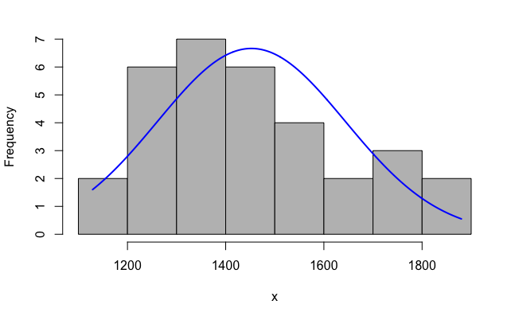

Hoozah! Looks pretty normal and you’ll take it, no transformation necessary!

Try the follow-up data:

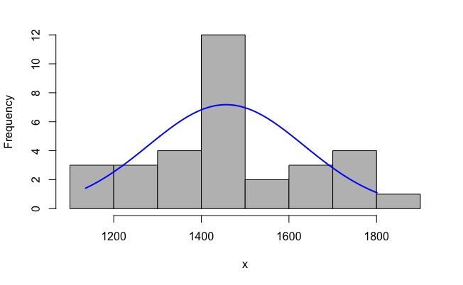

**Assumption: Homogeneity of Variance**

```r
leveneTest(repdat ~ Treatment.Group*contrasts, data=breakfast5)
```

```
Levene's Test for Homogeneity of Variance (center = median)
      Df F value Pr(>F)
group  3  1.0251  0.388
      60
```

Just like the other tests for homogeneity of variance, you want Levene’s test to be non-significant in order to pass this assumption. And lo and behold, it is! No need for correction!

### Correcting for Violations of Homogeneity of Variance

If you had violated the assumption of homogeneity of variance, you could correct for it by running a BoxCox transformation on your data, or by running a more robust ANOVA, that can handle a violation of this assumption.

### Sample Size

A repeated measures ANOVA requires a sample size of at least 20 per independent variable. You have that, so this assumption has been met.

### Sphericity

The only way to test for sphericity in R is to take a multivariate approach and make it work for an ANOVA. At this time, that is a bit too complex, but it may be covered later.

## **Analysis**

You will continue to use the `aov()` function, but add some additional arguments to it to make it repeated measures.

```r
RManova <- aov(repdat~contrasts+Error(Participant.Code), breakfast5)
summary(RManova)
```

[output not shown]

So what’s happening here is that you are calling the `aov()` function on your repeated data of metabolic rate by your timepoint, and then adding in an error term, which is what makes this a repeated measure - you are telling it that it should be looking within each participant, which is what ths part of the code does: `Error(Participant.Code)`. Finish it all off by specifying the dataset at the end and you are good to go. Call `summary()` on the results:

## Post Hocs

The overall test wasn’t significant, so no need to worry about post hocs.